# lab13

Anuj Desai

June 27, 2016

# Instructions

In this lab, you’ll be working with the `tents` dataset included in this folder. You may use any of the packages that we’ve covered in class so far. You’ll need to start by reading in the data with `read_csv` from `readr` of course.

## Histograms and Densities

1. Create a histogram of tent prices. You’ll need the `geom_histogram()` geometry.

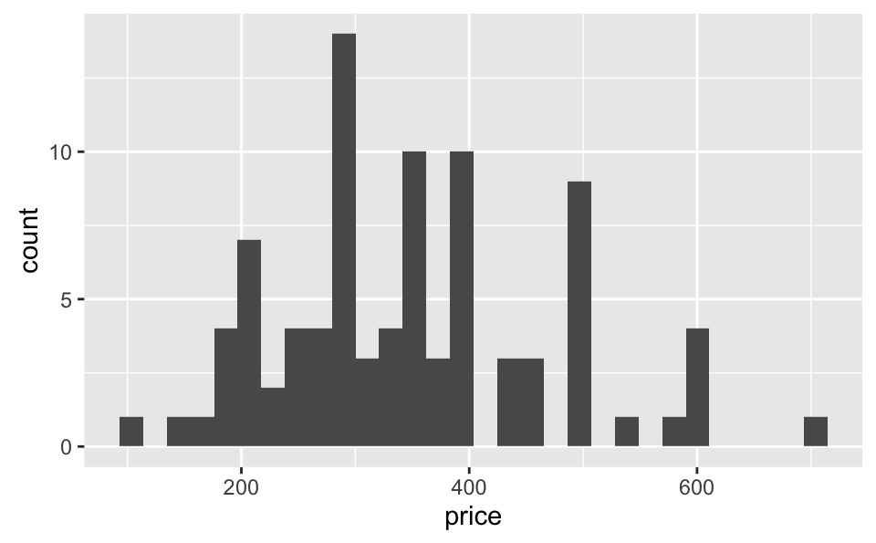

2. Adjust the binwidth to 50 with the `binwidth` argument of `geom_histogram()`.

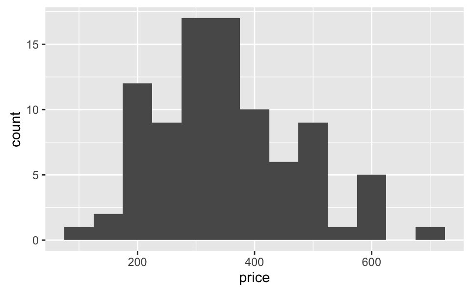

3. Add a density estimate layer to your plot in number 2 using `geom_density()`. You’ll need map `..density..` to the y aesthetic for this to work.

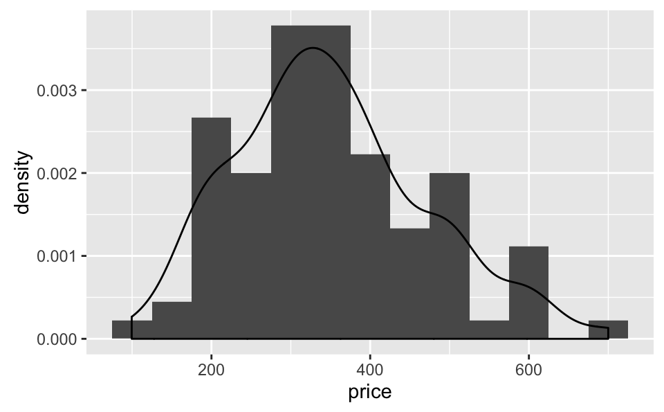

4. Generate a density `price`, colored by `bestuse`. You’ll probably want a fixed alpha value of 0.5.

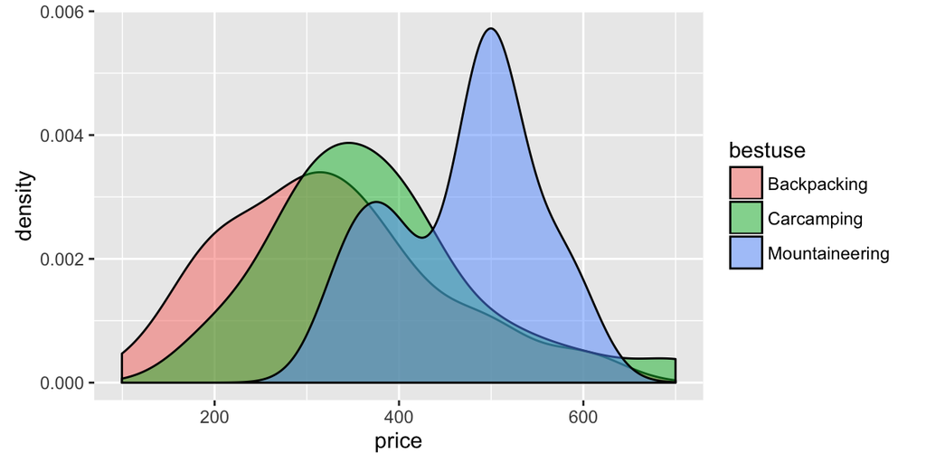

1. Generate a bar chart of with the counts of `brand`. `geom_bar`.

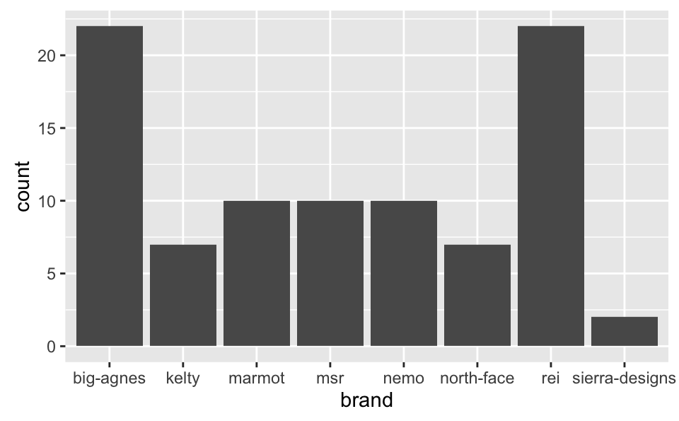

2. Modify the code from number 1 to add color for the brands.

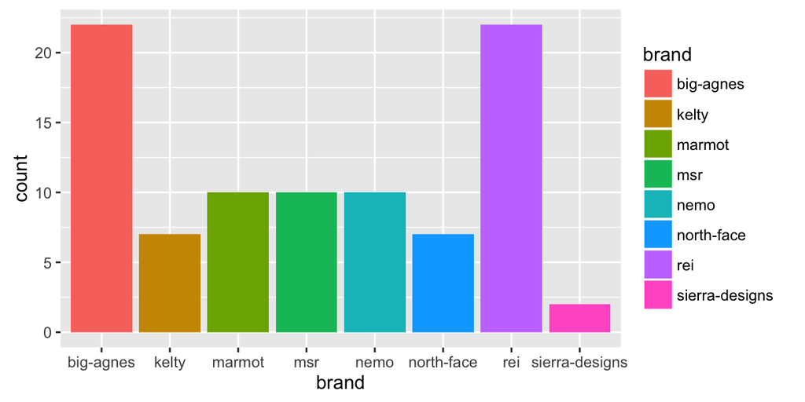

3. Create a bar chart of `brand` colored by `bestuse`.

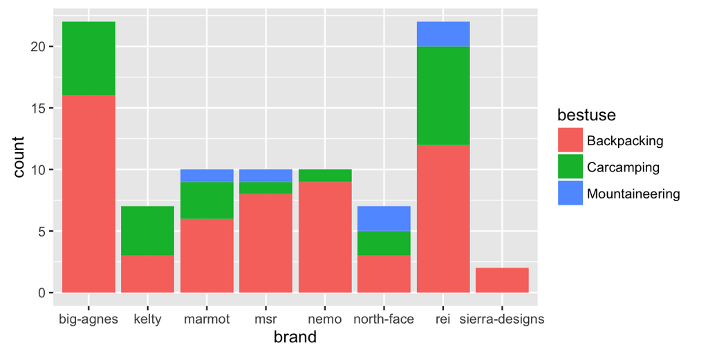

## Scatter Plots

1. Create a scatter plot of `height` vs. `weight`. Color and shape the points by `bestuse`.

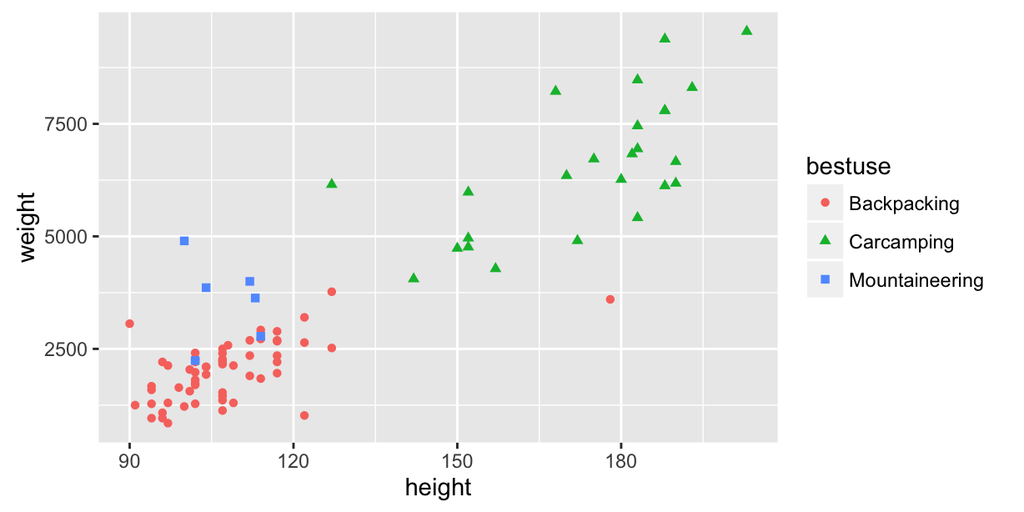

2. Add a line of best fit under the points using `geom_smooth`. Use `method = "lm"` to produce a line rather than a polynomial. Change `se` to `FALSE` to remove the confidence regions. Lastly, change the color of the line to `grey75`.

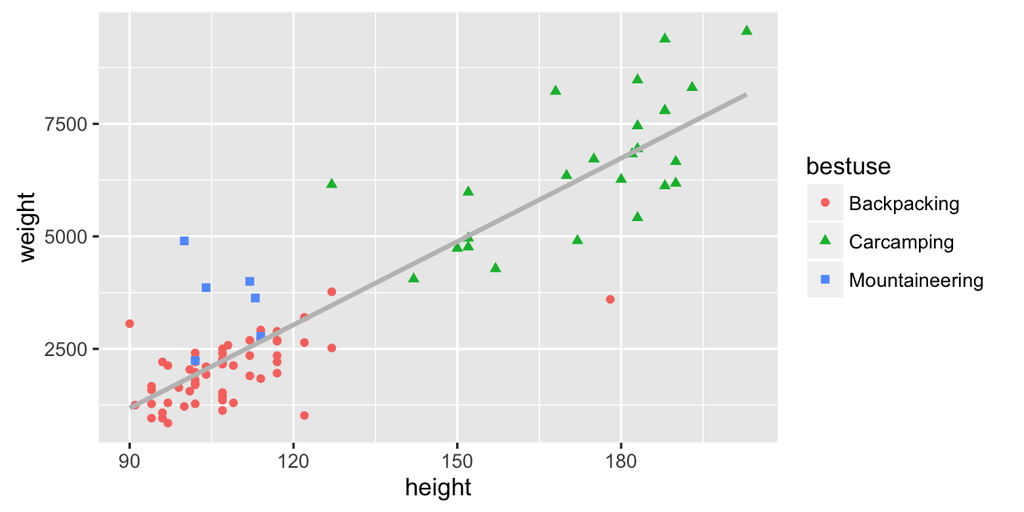

## Faceting

Create a scatter plots of `weight` vs `price`. Facet wrap by `capacity`. Color by `brand`.

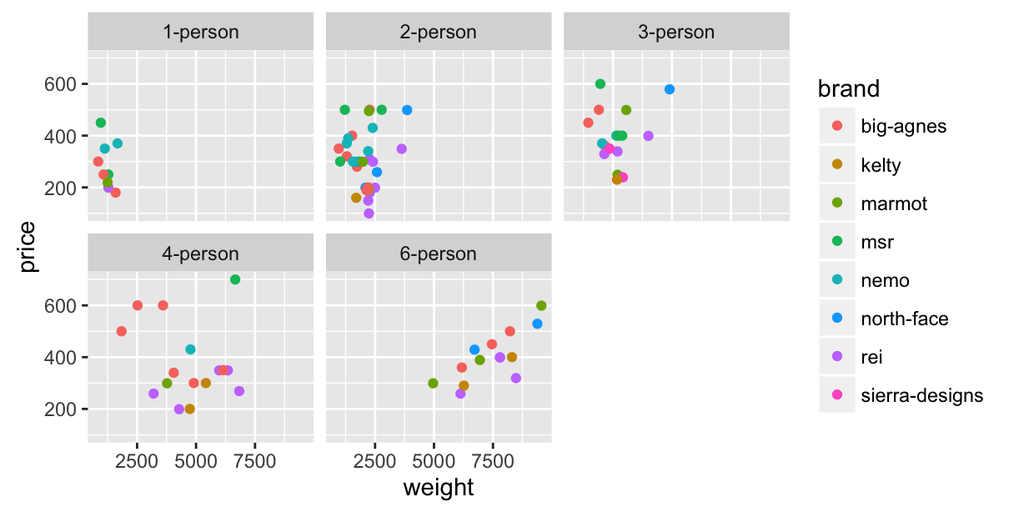

## In conjunction with wrangling

Try to reproduce the graph below, titles and all. You’ll need to wrangle the data some. The size of the points is 1.5, and the color of the line-of-best-fit is grey75.

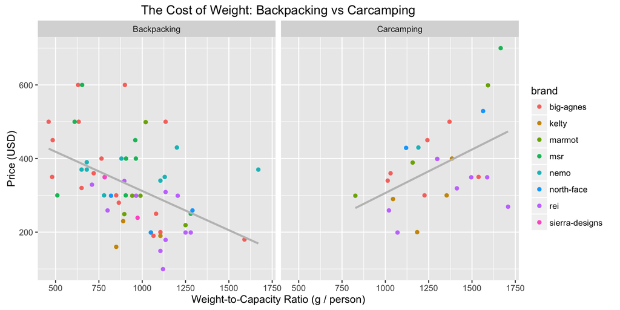